# Multiple Linear Regression with PyTorch

sumendar

2024-12-01

**Session Title: Multiple Linear Regression with PyTorch**

**Objective** : In this session, we will:

1. Build a **multiple linear regression model** using PyTorch.
2. Use **sample data** generated programmatically.
3. Explain **each line of code** in detail.
4. Understand the real-world relevance of multiple linear regression.

**1. What is Multiple Linear Regression?** **Theory** : - **Multiple Linear Regression** predicts a target variable (
$$y$$
) based on multiple independent variables (
$$x_1, x_2, \ldots, x_n$$
).

- The relationship is defined as:
  $$y = w_1x_1 + w_2x_2 + \ldots + w_nx_n + b$$

where: -
$$w_i$$
: Weights for each feature.

- $$b$$
  : Bias (intercept).
- $$y$$
  : Target variable. **Real-World Example** :
- Predicting **monthly rent** (
  $$y$$
  ) of a house based on:
  - **Size (sq ft)** (
    $$x_1$$
    ).
  - **Number of bedrooms** (
    $$x_2$$
    ).
  - **Distance to city center** (
    $$x_3$$
    ).

**2. sample Data Generation** We’ll create a dataset with three features (
$$x_1, x_2,
x_3$$
) and a target (
$$y$$
) using the formula:
$$y = 3x_1 + 2x_2 - x_3 + \text{noise}$$

```python
import torch
import torch.nn as nn
import numpy as np
import matplotlib.pyplot as plt

# Hyper-parameters
input_size = 3  # Three independent variables
output_size = 1  # One target variable
num_epochs = 100
learning_rate = 0.01

# Generate sampledata
np.random.seed(42)
x_train = np.random.rand(100, 3) * 10  # 100 samples, 3 features
weights = np.array([3.0, 2.0, -1.0])  # True weights
bias = 5.0  # True bias
noise = np.random.randn(100, 1)  # Add some noise

# Calculate y using the linear relationship
y_train = np.dot(x_train, weights.reshape(-1, 1)) + bias + noise
```

**Code Explanation** : 1. **Input Data** (
$$x$$
): - `x_train`: 100 samples with 3 features each, randomly generated.

- Example: A single row might represent a house with:
  - Size = 6.2 sq ft.
  - Bedrooms = 3.
  - Distance = 8.1 km.
2. **True Weights and Bias** :
- `weights`: The actual relationship between features and the target.
  - Size contributes positively (
    $$+3x_1$$
    ).
  - Bedrooms contribute positively (
    $$+2x_2$$
    ).
  - Distance contributes negatively (
    $$-x_3$$
    ).
- `bias`: A fixed base value for all predictions.
3. **Noise** :
- Adds randomness to simulate real-world data.
4. **Target Variable ($y$)** :
- Combines features, weights, bias, and noise to generate realistic predictions.

**3. Building the Model** **Model Definition** :

```python
# Define the linear regression model
model = nn.Linear(input_size, output_size)
```

- **Why a Linear Model?**
  - We are solving a linear regression problem, where the relationship between inputs and outputs is linear.
- **What Does `nn.Linear` Do?**
  - Creates a linear layer with:
    - `input_size` = 3 (three features).
    - `output_size` = 1 (one predicted value).

**4. Define Loss Function and Optimizer** **Loss Function** :

```python
criterion = nn.MSELoss()
```

- **Why MSE?**
  - Measures the average squared difference between predicted and actual values.
  - Smaller MSE = Better predictions. **Optimizer** :

```python
optimizer = torch.optim.SGD(model.parameters(), lr=learning_rate)
```

- **Why SGD?**
  - Adjusts weights based on the gradient of the loss function with respect to each weight.
  - `lr=0.01`: Controls how big each adjustment step is.

**5. Training the Model** **Training Loop** :

```python
for epoch in range(num_epochs):
    # Convert numpy arrays to torch tensors
    inputs = torch.from_numpy(x_train).float()
    targets = torch.from_numpy(y_train).float()

    # Forward pass: Compute predictions
    outputs = model(inputs)
    loss = criterion(outputs, targets)

    # Backward pass: Compute gradients
    optimizer.zero_grad()
    loss.backward()
    optimizer.step()

    if (epoch + 1) % 10 == 0:
        print(f"Epoch [{epoch+1}/{num_epochs}], Loss: {loss.item():.4f}")
```

[output not shown]

**Line-by-Line Explanation** : 1. **Convert Data to Tensors** : - PyTorch works with `torch.Tensor` objects, not `numpy`.

- `.float()`: Ensures the data is in floating-point format.
2. **Forward Pass** :
- `outputs = model(inputs)`: Feeds inputs through the model to get predictions.
3. **Calculate Loss** :
- `loss = criterion(outputs, targets)`: Compares predictions (`outputs`) to actual values (`targets`).
4. **Backward Pass** :
- `optimizer.zero_grad()`: Clears old gradients.
- `loss.backward()`: Calculates gradients for all weights and bias.
5. **Update Weights** :
- `optimizer.step()`: Adjusts weights and bias to minimize loss.
6. **Monitor Training** :
- Prints the loss every 10 epochs to track progress.

**6. Visualizing Results** **Plot the True vs. Predicted Values**

```python
# Evaluate the model
model.eval()
predicted = model(torch.from_numpy(x_train).float()).detach().numpy()

# Visualization
plt.figure(figsize=(10, 6))
plt.scatter(range(len(y_train)), y_train, color='blue', label='True Values')
plt.scatter(range(len(predicted)), predicted, color='red', label='Predicted Values')
plt.title('True vs Predicted Values')
plt.xlabel('Sample Index')
plt.ylabel('Target Value')
plt.legend()
plt.show()
```

[output not shown]

**Explanation** : 1. `model.eval()`: Switches the model to evaluation mode (disables gradient calculations).

2. `detach()`: Prevents tracking gradients for predictions (not needed during testing).
3. **Plot** :
- Blue dots: Actual values.
- Red dots: Predicted values.

**7. Saving the Model**

```python
torch.save(model.state_dict(), 'multiple_linear_regression.ckpt')
```

- Saves the trained weights and bias for later use.

**Complete Code**

```python
import torch
import torch.nn as nn
import numpy as np
import matplotlib.pyplot as plt

# Hyper-parameters
input_size = 3
output_size = 1
num_epochs = 100
learning_rate = 0.01

# Generate sampledata
np.random.seed(42)
x_train = np.random.rand(100, 3) * 10
weights = np.array([3.0, 2.0, -1.0])
bias = 5.0
noise = np.random.randn(100, 1)
y_train = np.dot(x_train, weights.reshape(-1, 1)) + bias + noise

# Linear regression model
model = nn.Linear(input_size, output_size)

# Loss and optimizer
criterion = nn.MSELoss()
optimizer = torch.optim.SGD(model.parameters(), lr=learning_rate)

# Train the model
for epoch in range(num_epochs):
    inputs = torch.from_numpy(x_train).float()
    targets = torch.from_numpy(y_train).float()

    outputs = model(inputs)
    loss = criterion(outputs, targets)

    optimizer.zero_grad()
    loss.backward()
    optimizer.step()

    if (epoch + 1) % 10 == 0:
        print(f"Epoch [{epoch+1}/{num_epochs}], Loss: {loss.item():.4f}")

# Visualize results
model.eval()
predicted = model(torch.from_numpy(x_train).float()).detach().numpy()
plt.figure(figsize=(10, 6))
plt.scatter(range(len(y_train)), y_train, color='blue', label='True Values')
plt.scatter(range(len(predicted)), predicted, color='red', label='Predicted Values')
plt.title('True vs Predicted Values')
plt.xlabel('Sample Index')
plt.ylabel('Target Value')
plt.legend()
plt.show()

# Save the model
torch.save(model.state_dict(), 'multiple_linear_regression.ckpt')
```

[output not shown]

**Learning Outcomes**  
1. **Understand multiple linear regression** and how to implement it in PyTorch.

2. Learn to **generate sample data** for experimentation.
3. Visualize **true vs. predicted values** to evaluate model performance.

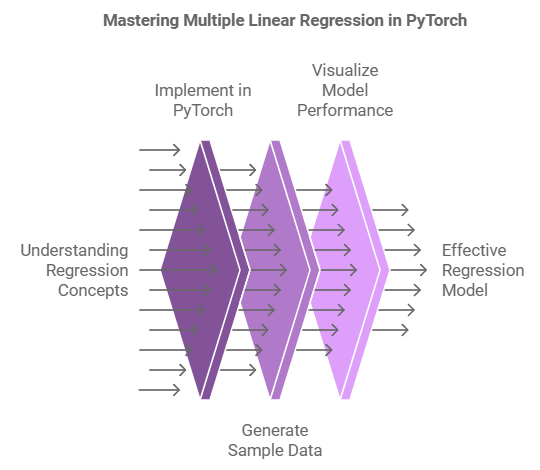